# HW3 - Data wrangling and simple modeling with R

misken

October 15, 2019

## Step 1 - Familiarize yourself with the data and the assignment

In this assignment you’ll do some exploratory data analysis with R on a dataset about airline flights into and out of of Detroit Metropolitan Airport during January of 2017. See the README.md file (it’s just a plain text file with markdown in it) for details about the data file.

You’ll be doing your work right in this R Markdown document to do some data wrangling, analysis and model building as well as to document the steps you did (and answer some questions I’ll throw at you).

You’ll notice a few “Hacker Extra” tasks thrown in at the end. These are for those of you who want to go a little above and beyond and attempt some more challenging tasks. And, feel free to do a some free form Hacker Extra style work yourself - in other words, do something beyond what was asked. You’ll learn more.

## Step 2 - Create a new R Markdown document

Save this R Markdown document with a new name - name it **HW3_wrangling_lm_[*your last name*].Rmd**. Mine would be called **HW3_wrangling_lm_isken.Rmd**. Save it into the same folder as this assignment.

## Step 3 - Create R project and explore data folder

Create an R project based on the folder containing this file. You’ll notice that there is a folder named **data**. Inside of it you’ll find the data file for this assignment - **flights_mi_2017.csv** as well as a few other data files. You’ll also find an folder named **images** that contains, well, images.

## Step 4 - Complete the following R tasks and answer questions

Now you’ll need to complete the following tasks in R. Just like we did in class, you should use a combination of markdown text (be concise, no need to write tons of text) to explain what you are doing and R code chunks to actually do it. When you are done, use the “Knit” button to generate an HTML file from your R Markdown. You’ll be submitting BOTH the completed R Markdown file as well as the generated HTML file. Just like in the previous homework, you’ll simply be compressing your entire project folder and uploading that into Moodle.

**HINT: I highly recommend skimming through the entire document before starting.**

Let’s load a few libraries we’ll need:

```r
library(dplyr)
```

```r
library(ggplot2)
library(stringr)
library(lubridate)
library(readr)
library(tidyr)
library(reshape2)
```

### Problem 1 - Reading the data in a few different ways

Let’s read the data into two `data.frames` named `flights1` and `flights2`. In the first case we’ll use the base R `read.csv` function and in the second we’ll use the **readr** function `read_csv`. For both we will use default arguments to start.

```r
flights1 <- read.csv("data/flights_mi_2017.csv")
flights2 <- read_csv("data/flights_mi_2017.csv")
```

Use the `str` function to check out the structure of both data frames.

```r
str(flights1)
```

```
## 'data.frame':    23009 obs. of  24 variables:
##  $ FL_DATE            : Factor w/ 31 levels "2017-01-01","2017-01-02",..: 1 1 1 1 1 1 1 1 1 1 ...
##  $ CARRIER            : Factor w/ 10 levels "AA","AS","B6",..: 1 1 1 1 1 1 1 1 1 2 ...
##  $ ORIGIN             : Factor w/ 108 levels "ABE","ALB","APN",..: 81 81 33 81 33 33 31 23 33 97 ...
##  $ ORIGIN_CITY_NAME   : Factor w/ 105 levels "Akron, OH","Albany, NY",..: 77 77 27 77 27 27 23 16 27 95 ...
##  $ ORIGIN_STATE_ABR   : Factor w/ 39 levels "AL","AR","AZ",..: 3 3 17 3 17 17 34 20 17 38 ...
##  $ DEST               : Factor w/ 104 levels "ABE","ALB","APN",..: 33 33 79 33 23 74 33 33 79 33 ...
##  $ DEST_CITY_NAME     : Factor w/ 101 levels "Akron, OH","Albany, NY",..: 27 27 74 27 16 18 27 27 74 27 ...
##  $ DEST_STATE_ABR     : Factor w/ 38 levels "AL","AR","AZ",..: 16 16 3 16 19 10 16 16 3 16 ...
##  $ CRS_DEP_TIME       : int  950 1710 1105 1940 1207 850 1825 1755 2035 815 ...
##  $ DEP_TIME           : int  946 1719 1103 1936 1158 844 1920 1800 2028 905 ...
##  $ DEP_DELAY          : int  -4 9 -2 -4 -9 -6 55 5 -7 50 ...
##  $ TAXI_OUT           : int  23 8 13 15 8 13 14 16 13 88 ...
##  $ WHEELS_OFF         : int  1009 1727 1116 1951 1206 857 1934 1816 2041 1033 ...
##  $ WHEELS_ON          : int  1525 2237 1310 54 1330 841 2227 1931 2241 1719 ...
##  $ TAXI_IN            : int  11 7 5 7 14 16 4 8 5 7 ...
##  $ CRS_ARR_TIME       : int  1542 2249 1336 122 1401 915 2157 1943 2304 1529 ...
##  $ ARR_TIME           : int  1536 2244 1315 101 1344 857 2231 1939 2246 1726 ...
##  $ ARR_DELAY          : int  -6 -5 -21 -21 -17 -18 34 -4 -18 117 ...
##  $ CANCELLED          : int  0 0 0 0 0 0 0 0 0 0 ...
##  $ CANCELLATION_CODE  : Factor w/ 5 levels "","A","B","C",..: 1 1 1 1 1 1 1 1 1 1 ...
##  $ CRS_ELAPSED_TIME   : int  232 219 271 222 114 85 152 108 269 254 ...
##  $ ACTUAL_ELAPSED_TIME: int  230 205 252 205 106 73 131 99 258 321 ...
##  $ AIR_TIME           : int  196 190 234 183 84 44 113 75 240 226 ...
##  $ DISTANCE           : int  1671 1671 1671 1671 500 235 986 500 1671 1927 ...
```

```r
str(flights2)
```

```
## Classes 'spec_tbl_df', 'tbl_df', 'tbl' and 'data.frame': 23009 obs. of  24 variables:
##  $ FL_DATE            : Date, format: "2017-01-01" "2017-01-01" ...
##  $ CARRIER            : chr  "AA" "AA" "AA" "AA" ...
##  $ ORIGIN             : chr  "PHX" "PHX" "DTW" "PHX" ...
##  $ ORIGIN_CITY_NAME   : chr  "Phoenix, AZ" "Phoenix, AZ" "Detroit, MI" "Phoenix, AZ" ...
##  $ ORIGIN_STATE_ABR   : chr  "AZ" "AZ" "MI" "AZ" ...
##  $ DEST               : chr  "DTW" "DTW" "PHX" "DTW" ...
##  $ DEST_CITY_NAME     : chr  "Detroit, MI" "Detroit, MI" "Phoenix, AZ" "Detroit, MI" ...
##  $ DEST_STATE_ABR     : chr  "MI" "MI" "AZ" "MI" ...
##  $ CRS_DEP_TIME       : num  950 1710 1105 1940 1207 ...
##  $ DEP_TIME           : num  946 1719 1103 1936 1158 ...
##  $ DEP_DELAY          : num  -4 9 -2 -4 -9 -6 55 5 -7 50 ...
##  $ TAXI_OUT           : num  23 8 13 15 8 13 14 16 13 88 ...
##  $ WHEELS_OFF         : num  1009 1727 1116 1951 1206 ...
##  $ WHEELS_ON          : num  1525 2237 1310 54 1330 ...
##  $ TAXI_IN            : num  11 7 5 7 14 16 4 8 5 7 ...
##  $ CRS_ARR_TIME       : num  1542 2249 1336 122 1401 ...
##  $ ARR_TIME           : num  1536 2244 1315 101 1344 ...
##  $ ARR_DELAY          : num  -6 -5 -21 -21 -17 -18 34 -4 -18 117 ...
##  $ CANCELLED          : num  0 0 0 0 0 0 0 0 0 0 ...
##  $ CANCELLATION_CODE  : chr  NA NA NA NA ...
##  $ CRS_ELAPSED_TIME   : num  232 219 271 222 114 85 152 108 269 254 ...
##  $ ACTUAL_ELAPSED_TIME: num  230 205 252 205 106 73 131 99 258 321 ...
##  $ AIR_TIME           : num  196 190 234 183 84 44 113 75 240 226 ...
##  $ DISTANCE           : num  1671 1671 1671 1671 500 ...
##  - attr(*, "spec")=
##   .. cols(
##   ..   FL_DATE = col_date(format = ""),
##   ..   CARRIER = col_character(),
##   ..   ORIGIN = col_character(),
##   ..   ORIGIN_CITY_NAME = col_character(),
##   ..   ORIGIN_STATE_ABR = col_character(),
##   ..   DEST = col_character(),
##   ..   DEST_CITY_NAME = col_character(),
##   ..   DEST_STATE_ABR = col_character(),
##   ..   CRS_DEP_TIME = col_double(),
##   ..   DEP_TIME = col_double(),
##   ..   DEP_DELAY = col_double(),
##   ..   TAXI_OUT = col_double(),
##   ..   WHEELS_OFF = col_double(),
##   ..   WHEELS_ON = col_double(),
##   ..   TAXI_IN = col_double(),
##   ..   CRS_ARR_TIME = col_double(),
##   ..   ARR_TIME = col_double(),
##   ..   ARR_DELAY = col_double(),
##   ..   CANCELLED = col_double(),
##   ..   CANCELLATION_CODE = col_character(),
##   ..   CRS_ELAPSED_TIME = col_double(),
##   ..   ACTUAL_ELAPSED_TIME = col_double(),
##   ..   AIR_TIME = col_double(),
##   ..   DISTANCE = col_double()
##   .. )
```

Summarize the differences in the default behavior between the `read.csv` function and the `read_csv` function with respect to how character variables and date variables are treated. Note any other differences you see between the two functions.

> Put your answer here…  
> “read.csv” read in all of the variables as factors and integers, including the FL_DATE data as a factor. “read_csv” read in FL_DATE as a date column but read in all of the columns that were factors above as character data.

Your goal now is to get the data read into a dataframe named `flights` that eventually has the following data types for each of the columns. You can:

- use either `read.csv` or `read_csv`
- use any argument values you want with either function (i.e. you do NOT need to just accept the default behavior)
- use additional commands after reading in the data to make any data type changes needed.
- IMPORTANT: If for some reason you simply cannot get the flights dataframe created correctly (but you should, there’s nothing tricky), I’ve included an RDS file in the data/ folder named **flights.rds**. You could simply read it in to a dataframe named flights - `flights <- readRDS("data/flights.rds")`. This is a last resort.

Here’s the target data types:

FL_DATE : Date or POSIXct CARRIER : Factor ORIGIN : Factor ORIGIN_CITY_NAME : Factor ORIGIN_STATE_ABR : Factor DEST : Factor DEST_CITY_NAME : Factor DEST_STATE_ABR : Factor CRS_DEP_TIME : int or num DEP_TIME : int or num DEP_DELAY : int or num TAXI_OUT : int or num WHEELS_OFF : int or num WHEELS_ON : int or num TAXI_IN : int or num CRS_ARR_TIME : int or num ARR_TIME : int or num ARR_DELAY : int or num CANCELLED : int or num CANCELLATION_CODE : Factor CRS_ELAPSED_TIME : int or num ACTUAL_ELAPSED_TIME: int or num AIR_TIME : int or num DISTANCE : int or num

After you have the `flights` dataframe created, remove `flights1` and `flights2`.

```r
## Read in the csv file
flights <- as.data.frame(flights1)

## Do any data type conversions needed
flights$FL_DATE <- as.POSIXct(flights$FL_DATE)

## Remove flights1 and flights2 from the workspace
rm(flights1, flights2)

## Check out the structure of your flights dataframe
str(flights)
```

```
## 'data.frame':    23009 obs. of  24 variables:
##  $ FL_DATE            : POSIXct, format: "2017-01-01" "2017-01-01" ...
##  $ CARRIER            : Factor w/ 10 levels "AA","AS","B6",..: 1 1 1 1 1 1 1 1 1 2 ...
##  $ ORIGIN             : Factor w/ 108 levels "ABE","ALB","APN",..: 81 81 33 81 33 33 31 23 33 97 ...
##  $ ORIGIN_CITY_NAME   : Factor w/ 105 levels "Akron, OH","Albany, NY",..: 77 77 27 77 27 27 23 16 27 95 ...
##  $ ORIGIN_STATE_ABR   : Factor w/ 39 levels "AL","AR","AZ",..: 3 3 17 3 17 17 34 20 17 38 ...
##  $ DEST               : Factor w/ 104 levels "ABE","ALB","APN",..: 33 33 79 33 23 74 33 33 79 33 ...
##  $ DEST_CITY_NAME     : Factor w/ 101 levels "Akron, OH","Albany, NY",..: 27 27 74 27 16 18 27 27 74 27 ...
##  $ DEST_STATE_ABR     : Factor w/ 38 levels "AL","AR","AZ",..: 16 16 3 16 19 10 16 16 3 16 ...
##  $ CRS_DEP_TIME       : int  950 1710 1105 1940 1207 850 1825 1755 2035 815 ...
##  $ DEP_TIME           : int  946 1719 1103 1936 1158 844 1920 1800 2028 905 ...
##  $ DEP_DELAY          : int  -4 9 -2 -4 -9 -6 55 5 -7 50 ...
##  $ TAXI_OUT           : int  23 8 13 15 8 13 14 16 13 88 ...
##  $ WHEELS_OFF         : int  1009 1727 1116 1951 1206 857 1934 1816 2041 1033 ...
##  $ WHEELS_ON          : int  1525 2237 1310 54 1330 841 2227 1931 2241 1719 ...
##  $ TAXI_IN            : int  11 7 5 7 14 16 4 8 5 7 ...
##  $ CRS_ARR_TIME       : int  1542 2249 1336 122 1401 915 2157 1943 2304 1529 ...
##  $ ARR_TIME           : int  1536 2244 1315 101 1344 857 2231 1939 2246 1726 ...
##  $ ARR_DELAY          : int  -6 -5 -21 -21 -17 -18 34 -4 -18 117 ...
##  $ CANCELLED          : int  0 0 0 0 0 0 0 0 0 0 ...
##  $ CANCELLATION_CODE  : Factor w/ 5 levels "","A","B","C",..: 1 1 1 1 1 1 1 1 1 1 ...
##  $ CRS_ELAPSED_TIME   : int  232 219 271 222 114 85 152 108 269 254 ...
##  $ ACTUAL_ELAPSED_TIME: int  230 205 252 205 106 73 131 99 258 321 ...
##  $ AIR_TIME           : int  196 190 234 183 84 44 113 75 240 226 ...
##  $ DISTANCE           : int  1671 1671 1671 1671 500 235 986 500 1671 1927 ...
```

### Problem 2 - Flights into and out of DTW

Use **dplyr** for all of the questions in this problem.

Find the number of flights into DTW by origin airport. Display the results in descending order by number of flights.

```r
flights %>%
  filter(DEST == "DTW") %>%
  group_by(ORIGIN) %>%
  summarize(num_flights = n()) %>%
  arrange(desc(num_flights))
```

```
## # A tibble: 102 x 2
##    ORIGIN num_flights
##    <fct>        <int>
##  1 ATL            457
##  2 ORD            411
##  3 LGA            284
##  4 BOS            283
##  5 MCO            276
##  6 LAS            267
##  7 FLL            262
##  8 TPA            262
##  9 RSW            261
## 10 BWI            255
## # ... with 92 more rows
```

Now use **dplyr** to compute the following summary statistics for ARR_DELAY, grouped by origin airport, for flights into DTW. We did this in the **dplyr** notes.

- number of flights
- mean and median
- min, max, 5th and 95th percentile
- IQR, standard deviation, range

```r
flights %>%
  filter(DEST == "DTW") %>%
  group_by(ORIGIN) %>%
  summarize(num_flights = n(),
          mean_arr_delay = mean(ARR_DELAY, na.rm = TRUE),
          median_arr_delay = median(ARR_DELAY,  na.rm = TRUE),
          min_arr_delay = min(ARR_DELAY, na.rm = TRUE),
          max_arr_delay = max(ARR_DELAY, na.rm = TRUE),
          p5_arr_delay = quantile(ARR_DELAY, 0.05, na.rm = TRUE),
          p95_arr_delay = quantile(ARR_DELAY, 0.95, na.rm = TRUE),
          iqr_arr_delay = IQR(ARR_DELAY, na.rm = TRUE),
          sdev_arr_delay = sd(ARR_DELAY, na.rm = TRUE),
          range_arr_delay = max(ARR_DELAY, na.rm = TRUE) - min(ARR_DELAY, na.rm = TRUE))
```

```
## # A tibble: 102 x 11
##    ORIGIN num_flights mean_arr_delay median_arr_delay min_arr_delay
##    <fct>        <int>          <dbl>            <dbl>         <int>
##  1 ABE             73          20.1              -1             -30
##  2 ALB             61          32.9              -3             -35
##  3 APN             31          17.7               1             -32
##  4 ATL            457           6.94             -6.5           -25
##  5 ATW             63          44.6              -2             -34
##  6 AUS             31          -9.84            -18             -31
##  7 AVP             45          49.9               2             -37
##  8 AZO             78           3.53            -11.5           -49
##  9 BDL            101          -6.38            -13             -42
## 10 BGM             58           6.35             -6.5           -33
## # ... with 92 more rows, and 6 more variables: max_arr_delay <int>,
## #   p5_arr_delay <dbl>, p95_arr_delay <dbl>, iqr_arr_delay <dbl>,
## #   sdev_arr_delay <dbl>, range_arr_delay <int>
```

Repeat the above query but just include origin airports for which there were at least 100 flights.

```r
flights %>%
  filter(DEST == "DTW") %>%
  group_by(ORIGIN) %>%
  filter(n() > 100) %>%
  summarize(num_flights = n(),
          mean_arr_delay = mean(ARR_DELAY, na.rm = TRUE),
          median_arr_delay = median(ARR_DELAY,  na.rm = TRUE),
          min_arr_delay = min(ARR_DELAY, na.rm = TRUE),
          max_arr_delay = max(ARR_DELAY, na.rm = TRUE),
          p5_arr_delay = quantile(ARR_DELAY, 0.05, na.rm = TRUE),
          p95_arr_delay = quantile(ARR_DELAY, 0.95, na.rm = TRUE),
          iqr_arr_delay = IQR(ARR_DELAY, na.rm = TRUE),
          sdev_arr_delay = sd(ARR_DELAY, na.rm = TRUE),
          range_arr_delay = max(ARR_DELAY, na.rm = TRUE) - min(ARR_DELAY, na.rm = TRUE))
```

```
## # A tibble: 33 x 11
##    ORIGIN num_flights mean_arr_delay median_arr_delay min_arr_delay
##    <fct>        <int>          <dbl>            <dbl>         <int>
##  1 ATL            457          6.94              -6.5           -25
##  2 BDL            101         -6.38             -13             -42
##  3 BNA            195         -0.868             -9             -30
##  4 BOS            283         -3.11              -9             -41
##  5 BUF            111          4.43              -9.5           -38
##  6 BWI            255          0.614             -8             -34
##  7 CLT            198          4.45              -5             -32
##  8 DCA            132         10.1               -8             -27
##  9 DEN            251          5.86              -5             -49
## 10 DFW            210          5.53              -2             -30
## # ... with 23 more rows, and 6 more variables: max_arr_delay <int>,
## #   p5_arr_delay <dbl>, p95_arr_delay <dbl>, iqr_arr_delay <dbl>,
## #   sdev_arr_delay <dbl>, range_arr_delay <int>
```

Now for something more challenging.

You start to wonder about the difference between the number of flights into DTW from a particular airport and the number of flights out of DTW for that same airport. For example, consider ATL:

```r
num_in_ATL <- flights %>%
  filter(ORIGIN == 'ATL') %>%
  summarize(num_flights = n())

num_out_ATL <- flights %>%
  filter(DEST == 'ATL') %>%
  summarize(num_flights = n())

# Convert resulting single valued dataframe to a number
num_in_ATL <- as.numeric(num_in_ATL)
num_out_ATL <- as.numeric(num_out_ATL)

sprintf("Num in to ATL = %i, Num out of ATL = %i", num_in_ATL, num_out_ATL)
```

```
## [1] "Num in to ATL = 672, Num out of ATL = 674"
```

BTW, instead of using `as.numeric` above to convert the result from a dataframe into a number, we could also use the `pull()` function in our **dplyr** statement.

```r
num_out_ATL <- flights %>%
  filter(DEST == 'ATL') %>%
  summarize(num_flights = n()) %>%
  pull()
```

Of course we don’t want to do this just for one airport and we certainly don’t way to repeat the above approach for each airport. This is where R really shines in that we can design a multistep workflow that does something a little more difficult.

We want to do the following.

- Create a dataframe named `num_in` that counts flights by ORIGIN (don’t include ‘DTW’ as an ORIGIN).
- Create a dataframe named `num_out` that counts flights by DEST (again, don’t include ‘DTW’ as a DEST).
- Use one of **dplyr**’s `*_join` commands to join the two dataframes together by ORIGIN = DEST, creating a new dataframe named `inout`.
- Rename the columns in `inout` using the vector c(“AIRPORT”, “num_in”, “num_out”)
- Replace any NAs in `inout` with 0.
- Compute a new column in `inout` called `balance` that is `num_in - num_out`
- Display `inout` sorted in descending order by balance to see which airports have the greatest discrepancy between number of flights into DTW and number of flights from DTW.

```r
# Of course you already did queries similar to these up above
#
num_in <-
flights %>%
  filter(ORIGIN != "DTW") %>%
  group_by(ORIGIN) %>%
  summarize(num_flights = n())
#
num_out <- flights %>%
  filter(DEST != "DTW") %>%
  group_by(DEST) %>%
  summarize(num_flights = n())
```

```r
# Join the num_in and num_out dataframes  ORIGIN = DEST
inout <- full_join(num_in, num_out, by = c('ORIGIN' = 'DEST'))
## Rename columns in new inout dataframe
names(inout) <- c("AIRPORT", "num_in", "num_out")

## Replace NA values in the num_in, num_out with 0.
# https://stackoverflow.com/questions/8161836/how-do-i-replace-na-values-with-zeros-in-an-r-dataframe

inout[is.na(inout)] <- 0

## Compute difference between number of flights in and number out
inout$balance <- inout$num_in - inout$num_out


## Display sorted descending by balance and num_out
inout %>%
  arrange(desc(balance), desc(num_out))
```

```
## # A tibble: 107 x 4
##    AIRPORT num_in num_out balance
##    <chr>    <int>   <dbl>   <dbl>
##  1 ORD       1222    1197      25
##  2 ATW         63      42      21
##  3 CMH         58      39      19
##  4 DSM         39      20      19
##  5 DFW        210     193      17
##  6 MKE        161     154       7
##  7 RDU         77      72       5
##  8 BOS        283     279       4
##  9 JFK         36      32       4
## 10 CLT        198     195       3
## # ... with 97 more rows
```

### Problem 3 - converting wide to long data to facilitate plotting

You decide you want to create a bar plot showing the total number of flights by hour of day and day of week. One of your colleagues, trying to be helpful, creates a file for you named **dow_hour_summary.csv**. However, the file they created was based on January 2016 data. Let’s read it in.

```r
dow_hour_summary_2016 <- read_csv("data/dow_hour_summary.csv")
```

Uh oh. The data is in “wide format”. You want to facet by day of week but those are the column headings. Use either the **reshape2** or **tidyr** package to convert this data into long format and then create a bar chart showing the total number of flights by hour of day and faceted by day of week.

```r
# added library(reshape2) where we loaded the other libraries up top

dow_hour_summary_2016_long <- melt(dow_hour_summary_2016, id.vars = c("CRS_DEP_HOUR"),
                                   variable.name = "day_of_week", value.name = "flights")

head(dow_hour_summary_2016_long)
```

```
##   CRS_DEP_HOUR day_of_week flights
## 1            5           1      10
## 2            6           1      41
## 3            7           1      73
## 4            8           1     146
## 5            9           1      20
## 6           10           1     114
```

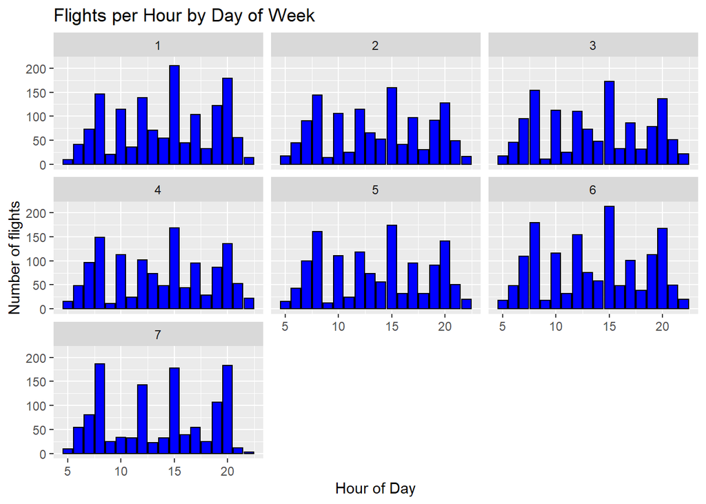

```r
 ggplot(dow_hour_summary_2016_long, aes(x=CRS_DEP_HOUR, y=flights)) +
   geom_bar(stat="identity", colour="black", fill="blue") +
   labs(title = "Flights per Hour by Day of Week") +
   xlab("Hour of Day") +
   ylab("Number of flights") +
   facet_wrap(~day_of_week)
```

For the rest of the problems we are just interested in flights **out** of DTW. To make our life a little easier, let’s create a dataframe called `flights_out`.

```r
flights_out <- flights %>%
  filter(ORIGIN == 'DTW')
```

### Problem 4 - Engineer new features to facilitate time of day analysis

Remember, use the new `flights_out` dataframe for the rest of the assignment unless otherwise specified.

Create a new field showing the hour of day for the flight departure called CRS_DEP_HOUR based on CRS_DEP_TIME. Check it by displaying the first 10 rows and the CRS_DEP_HOUR and CRS_DEP_TIME fields. Use can use **dplyr** and its `mutate()` function for this problem or you can use base R commands. Even better, show how to do it both ways. HINT: We did this in class.

```r
## Add new departure hour field

flights_out$CRS_DEP_HOUR <- flights_out$CRS_DEP_TIME %/% 100

## or using mutate...
mutate(flights_out, CRS_DEP_HOUR_2 = CRS_DEP_TIME %/% 100) %>%
  head(10)
```

```
##       FL_DATE CARRIER ORIGIN ORIGIN_CITY_NAME ORIGIN_STATE_ABR DEST
## 1  2017-01-01      AA    DTW      Detroit, MI               MI  PHX
## 2  2017-01-01      AA    DTW      Detroit, MI               MI  CLT
## 3  2017-01-01      AA    DTW      Detroit, MI               MI  ORD
## 4  2017-01-01      AA    DTW      Detroit, MI               MI  PHX
## 5  2017-01-01      AS    DTW      Detroit, MI               MI  SEA
## 6  2017-01-01      B6    DTW      Detroit, MI               MI  BOS
## 7  2017-01-01      EV    DTW      Detroit, MI               MI  AUS
## 8  2017-01-01      EV    DTW      Detroit, MI               MI  MCI
## 9  2017-01-01      EV    DTW      Detroit, MI               MI  OKC
## 10 2017-01-01      EV    DTW      Detroit, MI               MI  MSN
##       DEST_CITY_NAME DEST_STATE_ABR CRS_DEP_TIME DEP_TIME DEP_DELAY
## 1        Phoenix, AZ             AZ         1105     1103        -2
## 2      Charlotte, NC             NC         1207     1158        -9
## 3        Chicago, IL             IL          850      844        -6
```

[output cut: 40 more lines]

```r
## Display first 10 rows and just the CRS_DEP_HOUR and CRS_DEP_TIME fields
# flights_out[???, ???]
flights_out %>% select(CRS_DEP_HOUR, CRS_DEP_TIME) %>%
  head(10)
```

```
##    CRS_DEP_HOUR CRS_DEP_TIME
## 1            11         1105
## 2            12         1207
## 3             8          850
## 4            20         2035
## 5            16         1630
## 6            19         1915
## 7             8          833
## 8            12         1211
## 9            15         1535
## 10           20         2032
```

In addition, you decide that you’d like to create a “coarser” version based on “departure period”. Let’s call it CRS_DEP_PRD. The values of this new variable are as follows:

1 if CRS_DEP_HOUR in [0,5] 2 if CRS_DEP_HOUR in [6,12] 3 if CRS_DEP_HOUR in [13,18] 4 if CRS_DEP_HOUR in [19,23]

See http://www.cookbook-r.com/Manipulating_data/Recoding_data/ for ideas. After creating the departure period field, makes sure you convert it to a factor if it’s not already. HINT: The `cut()` function is useful.

```r
# By default, the ranges are open on the left, and closed (includes cut point) on the right
# To set it so that ranges are closed on the left and open on the right, like [7,9), use right=FALSE

flights_out$CRS_DEP_PRD <- cut(flights_out$CRS_DEP_HOUR,
                     breaks=c(0, 5, 12, 18, 23),
                     labels=c("0-5","6-12","13-18","19-23"))
# Did it work?
flights_out %>% select(CRS_DEP_HOUR, CRS_DEP_PRD) %>%
  head(10)
```

```
##    CRS_DEP_HOUR CRS_DEP_PRD
## 1            11        6-12
## 2            12        6-12
## 3             8        6-12
## 4            20       19-23
## 5            16       13-18
## 6            19       19-23
## 7             8        6-12
## 8            12        6-12
## 9            15       13-18
## 10           20       19-23
```

```r
# yep :) ... and as a bonus CRS_DEP_PRD is already a factor
```

Finally, create a field FL_DOW based on FL_DATE representing the day of week of the flight. The **lubridate** package will be helpful.

```r
# Create day of week field called FL_DOW
flights_out$FL_DOW <- wday(ymd(flights_out$FL_DATE), label = TRUE, abbr = FALSE)

# Did it work?
flights_out %>% select(FL_DATE, FL_DOW) %>%
  head(10)
```

```
##       FL_DATE FL_DOW
## 1  2017-01-01 Sunday
## 2  2017-01-01 Sunday
## 3  2017-01-01 Sunday
## 4  2017-01-01 Sunday
## 5  2017-01-01 Sunday
## 6  2017-01-01 Sunday
## 7  2017-01-01 Sunday
## 8  2017-01-01 Sunday
## 9  2017-01-01 Sunday
## 10 2017-01-01 Sunday
```

```r
flights_out %>% select(FL_DATE, FL_DOW) %>%
  tail(10)
```

```
##         FL_DATE  FL_DOW
## 9674 2017-01-31 Tuesday
## 9675 2017-01-31 Tuesday
## 9676 2017-01-31 Tuesday
## 9677 2017-01-31 Tuesday
## 9678 2017-01-31 Tuesday
## 9679 2017-01-31 Tuesday
## 9680 2017-01-31 Tuesday
## 9681 2017-01-31 Tuesday
## 9682 2017-01-31 Tuesday
## 9683 2017-01-31 Tuesday
```

```r
# Hooray!
```

### Problem 5 - Do group by analysis on CRS_DEP_PRD

Are departure delays related to departure period? Start by computing basic summary statistics for DEP_DELAY by CRS_DEP_PRD. Of course you already know how to do this from previous questions in this assignment. If you weren’t able to create CRS_DEP_PRD, then use CRS_DEP_HOUR.

Use **dplyr**.

```r
ddelay_period_summary <- flights_out %>%
  group_by(CRS_DEP_PRD) %>%
  summarize(num_flights = n(),
        mean_dep_delay = mean(DEP_DELAY, na.rm = TRUE),
        median_dep_delay = median(DEP_DELAY,  na.rm = TRUE),
        min_dep_delay = min(DEP_DELAY, na.rm = TRUE),
        max_dep_delay = max(DEP_DELAY, na.rm = TRUE),
        p5_dep_delay = quantile(DEP_DELAY, 0.05, na.rm = TRUE),
        p95_dep_delay = quantile(DEP_DELAY, 0.95, na.rm = TRUE),
        iqr_dep_delay = IQR(DEP_DELAY, na.rm = TRUE),
        sdev_dep_delay = sd(DEP_DELAY, na.rm = TRUE),
        range_dep_delay = max(DEP_DELAY, na.rm = TRUE) - min(DEP_DELAY, na.rm = TRUE))

head(ddelay_period_summary)
```

```
## # A tibble: 4 x 11
##   CRS_DEP_PRD num_flights mean_dep_delay median_dep_delay min_dep_delay
##   <fct>             <int>          <dbl>            <dbl>         <int>
## 1 0-5                  96           7.5                -3           -12
## 2 6-12               4298           9.64               -2           -23
## 3 13-18              3013          14.7                -1           -19
## 4 19-23              2276          19.3                -1           -19
## # ... with 6 more variables: max_dep_delay <int>, p5_dep_delay <dbl>,
## #   p95_dep_delay <dbl>, iqr_dep_delay <dbl>, sdev_dep_delay <dbl>,
## #   range_dep_delay <int>
```

```r
# tail(ddelay_period_summary) - Do not need a head & a tail. There are only 4 categories
```

> Your interepretation here …  
> There are fewer (by a lot) flights departing from DTW in the 0-5 hours. Flights out spike in the 6-12 hours and then decrease for the rest of the day. The mean delay increases as the day goes on, although the median delay for all time segments is a negative number indicating an early departure. The 5th & 95th %’s of delay also increase but not as drastically as the original mean statistic might have alluded to. This could indicate that there is some outlier data pulling our means up. Standard deviation and range are also increased with the later time ranges.

**Hacker Extra** If you’d like, make boxplots or violin plots of DEP_DELAY by CRS_DEP_PRD. They won’t be pretty. Make them easier to read.

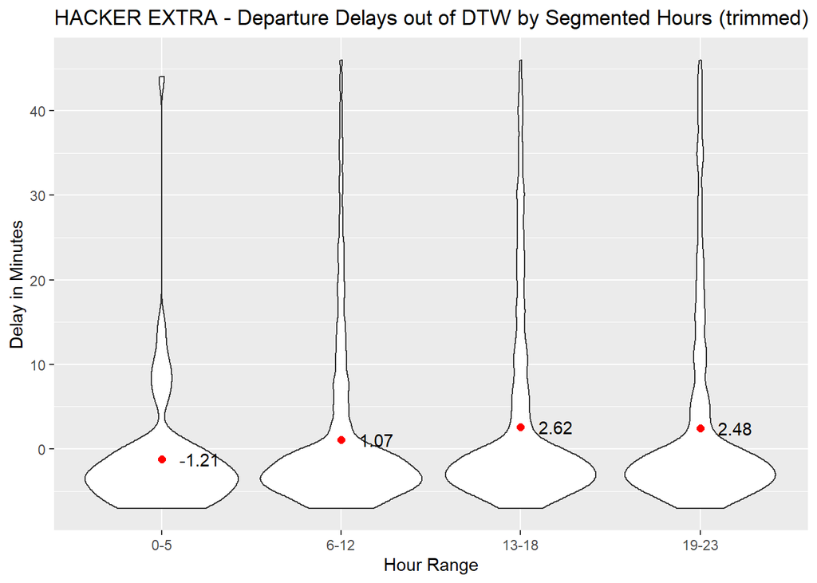

```r
ggplot(flights_out, aes(y=DEP_DELAY, x=CRS_DEP_PRD)) +
  geom_violin(na.rm = TRUE) +

  # The following trims the data to that included within the 10th & 90th percentile to deal with outlier issue
  scale_y_continuous(limits = quantile(flights_out$DEP_DELAY, c(0.1, 0.9), na.rm = TRUE)) +

  # The following adds a point on each violin plot which shows the mean
  stat_summary(fun.y=mean, geom="point", size=2, color="red") +
  geom_text(stat = 'summary', fun.y=mean, aes(label = round(..y.., 2)), nudge_x = 0.1, hjust = 0) +

  #titles/labels...
  labs(title = "HACKER EXTRA - Departure Delays out of DTW by Segmented Hours (trimmed)") +
  ylab("Delay in Minutes") +
  xlab("Hour Range")
```

### Problem 6 - A scatterplot of DEP_DELAY by CRS_DEP_HOUR

Create two versions, a standard scatter plot and one with “jitter”.

Jitter is useful when you have many duplicate points that obscure each other.

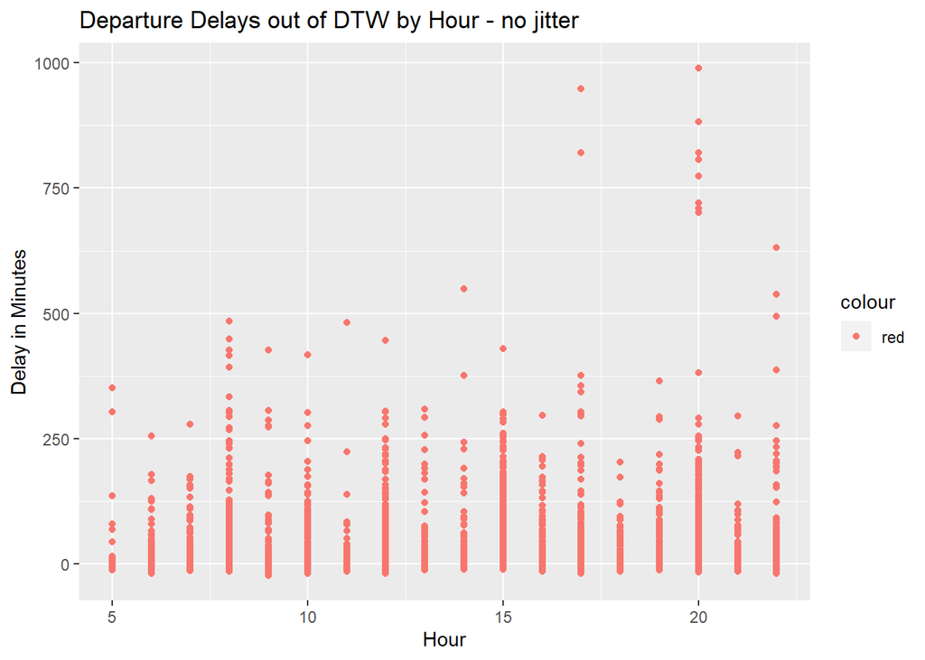

```r
ggplot(flights_out) +
  geom_point(aes(y=DEP_DELAY, x=CRS_DEP_HOUR, color = "red")) +
  ggtitle("Departure Delays out of DTW by Hour - no jitter") +
  ylab("Delay in Minutes") +
  xlab("Hour")
```

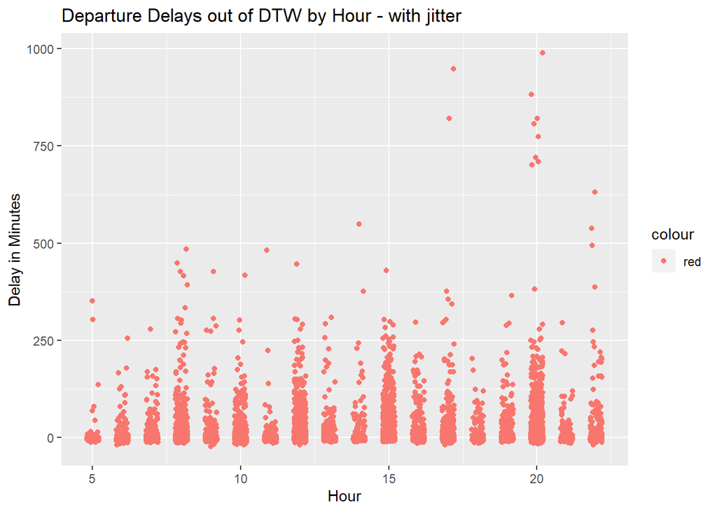

```r
#
ggplot(flights_out) +
  geom_point(aes(y=DEP_DELAY, jitter(x=CRS_DEP_HOUR), color = "red")) +
  ggtitle("Departure Delays out of DTW by Hour - with jitter") +
  ylab("Delay in Minutes") +
  xlab("Hour")
```

### Problem 7 - Are departure delays related to day of week?

Use plots and/or group by analysis to take a first look at these questions.

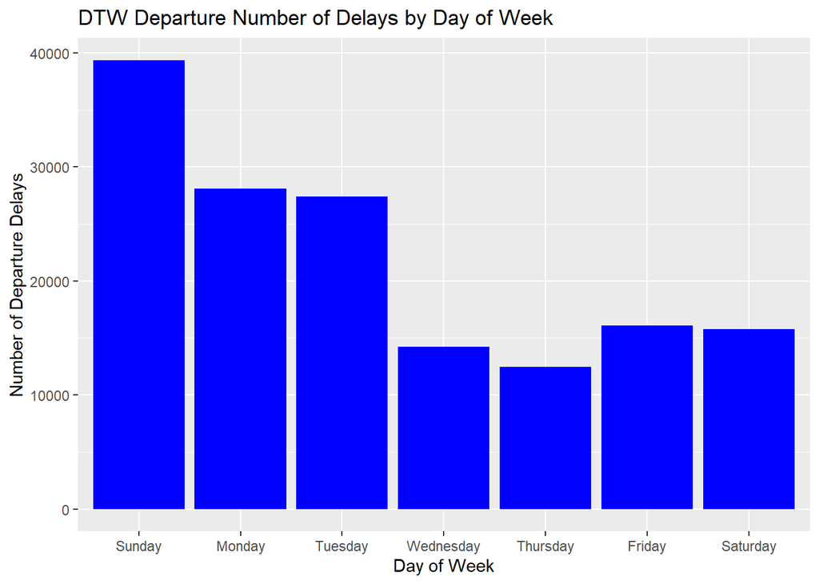

```r
flights_out %>%
  filter(DEP_DELAY > 0) %>%
  ggplot(aes(x=FL_DOW, y=DEP_DELAY)) +
  geom_bar(stat="identity", fill="blue") +
  labs(title = "DTW Departure Number of Delays by Day of Week") +
  ylab("Number of Departure Delays") +
  xlab("Day of Week")
```

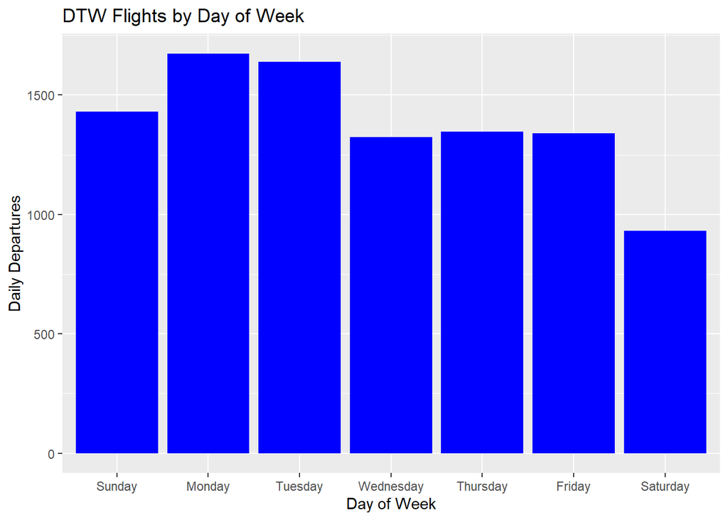

```r
# Now calculate delays as a percentage of the number of flights that go out on each day
#There is probably an easier way to do this... but I'm goin with what I know how to do ;)

#summarize tot flights per day
tot_flights <- flights_out %>%
  group_by(FL_DOW) %>%
  summarize(tot_num_flights = n())
#Summarize delayed flights by day
del_flights <- flights_out %>%
  group_by(FL_DOW) %>%
  filter(DEP_DELAY > 0) %>%
  summarize(del_num_flights = n())
#join the two and calculate delays as a percentage of flights
percent_del <- full_join(tot_flights, del_flights, by = c('FL_DOW' = 'FL_DOW')) %>%
  mutate(per_del = del_num_flights / tot_num_flights)
#percent_del

#Lets look at the total number of flights per day...
percent_del %>%
  ggplot(aes(x=FL_DOW, y=tot_num_flights)) +
  geom_bar(stat="identity", fill="blue") +
  labs(title = "DTW Flights by Day of Week") +
  ylab("Daily Departures") +
  xlab("Day of Week")
```

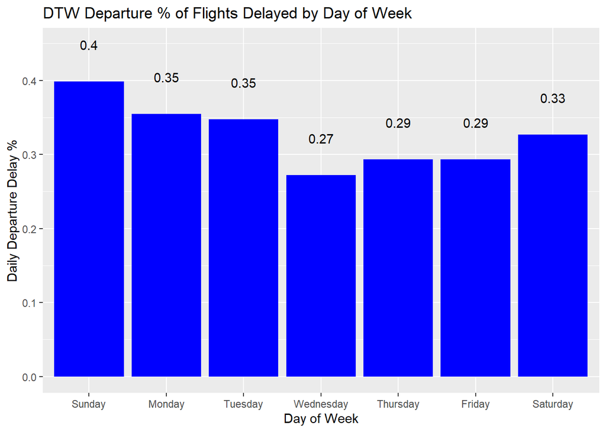

```r
# make a pretty graph of Departure %'s
percent_del %>%
  ggplot(aes(x=FL_DOW, y=per_del)) +
  geom_bar(stat="identity", fill="blue") +
  labs(title = "DTW Departure % of Flights Delayed by Day of Week") +
  ylab("Daily Departure Delay %") +
  xlab("Day of Week") +
  geom_text(aes(x = FL_DOW,
  y = per_del + 0.05, label = round(per_del, 2)))
```

```r
#When calculated as a percentage of flights the days are more similar than at first glance
```

> At first glance it seems like the day of the week has an impact on flight delays. Graphing the number of flights shows that Sunday has way more delays than any of the other days, with Monday and Tuesday nearly tying for second. However, if you take into account the total number of flights on each day the picture is not as drastic. Sunday still has the most delays, at around 40% of flights, but the other days are not as different as they originally seemed. Wednesday seems to be the best day of the week to avoid delays as only 27% of flights are delayed on that day.

### Problem 8 - Linear regression models

Given the limited number of fields we have and the fact that we only have one month of data, do you think we can build a linear regression model to predict DEP_DELAY that outperforms a simple null model which simply predicts the overall mean departure delay?

I’ll partition `flights_out` into a training and test set. Use the training data to build your model. Then use your model to make predictions on the test set and compute RMSE for your predictions. Compare to the RMSE I compute below for the naive null model based on just predicting overall mean delay for everyone.

```r
# Simple partition into train and test set
set.seed(447)
testrecs <- sample(nrow(flights_out), floor(0.20 * nrow(flights_out)))
flights_out_train <- flights_out[-testrecs,]
flights_out_test <- flights_out[testrecs,]

# Get rid of cancelled flights
flights_out_train <- flights_out_train %>%
  filter(CANCELLED == 0)

flights_out_test <- flights_out_test %>%
  filter(CANCELLED == 0)
```

Create our “null model” which is simply the overall mean DEP_DELAY for all the flights in the training dataset. Think of a null model as a very simple “model” that any other model better be able to beat if it’s going to be any good.

```r
null_pred <- mean(flights_out_train$DEP_DELAY)
null_pred
```

```
## [1] 13.25305
```

```r
# Load MLmetrics library to get rmse() function
library(MLmetrics)
null_rmse <- RMSE(flights_out_test$DEP_DELAY, null_pred)
null_rmse
```

```
## [1] 47.18596
```

Try to build a linear regression model to predict DEP_DELAY that has a lower RMSE than this on the test data. Feel free to create any new fields you’d like as long as you don’t include information that would not be available the day before the actual flight - i.e. we need to avoid being accidentally “clairvoyant”.

```r
# possible important variables - CARRIER, DEST, CRS_DEP_TIME v CRS_DEP_HOUR v CRS_DEP_PRD, TAXI_OUT, FL_DOW
#Check for correlation issues
summary(flights_out_train)
```

```
##     FL_DATE                       CARRIER         ORIGIN
##  Min.   :2017-01-01 00:00:00   DL     :3336   DTW    :7615
##  1st Qu.:2017-01-09 00:00:00   OO     :1873   ABE    :   0
##  Median :2017-01-17 00:00:00   EV     : 618   ALB    :   0
##  Mean   :2017-01-16 10:52:57   NK     : 602   APN    :   0
##  3rd Qu.:2017-01-24 00:00:00   WN     : 458   ATL    :   0
##  Max.   :2017-01-31 00:00:00   AA     : 423   ATW    :   0
##                                (Other): 305   (Other):   0
##                        ORIGIN_CITY_NAME ORIGIN_STATE_ABR      DEST
##  Detroit, MI                   :7615    MI     :7615     ATL    : 375
##  Akron, OH                     :   0    AL     :   0     ORD    : 330
##  Albany, NY                    :   0    AR     :   0     MCO    : 225
##  Allentown/Bethlehem/Easton, PA:   0    AZ     :   0     LGA    : 224
##  Alpena, MI                    :   0    CA     :   0     BOS    : 220
##  Appleton, WI                  :   0    CO     :   0     LAS    : 214
##  (Other)                       :   0    (Other):   0     (Other):6027
##         DEST_CITY_NAME DEST_STATE_ABR  CRS_DEP_TIME     DEP_TIME
##  Chicago, IL   : 482   FL     : 991   Min.   : 525   Min.   :   9
##  Atlanta, GA   : 375   NY     : 589   1st Qu.: 955   1st Qu.: 953
##  New York, NY  : 247   MI     : 548   Median :1405   Median :1420
##  Orlando, FL   : 225   IL     : 540   Mean   :1390   Mean   :1400
##  Boston, MA    : 220   PA     : 395   3rd Qu.:1758   3rd Qu.:1814
##  Fort Myers, FL: 214   GA     : 375   Max.   :2220   Max.   :2400
##  (Other)       :5852   (Other):4177
##    DEP_DELAY         TAXI_OUT        WHEELS_OFF     WHEELS_ON
##  Min.   :-23.00   Min.   :  5.00   Min.   :   2   Min.   :   1
##  1st Qu.: -4.00   1st Qu.: 13.00   1st Qu.:1010   1st Qu.:1112
##  Median : -2.00   Median : 17.00   Median :1434   Median :1533
##  Mean   : 13.25   Mean   : 22.53   Mean   :1430   Mean   :1516
##  3rd Qu.:  7.00   3rd Qu.: 28.00   3rd Qu.:1834   3rd Qu.:1943
##  Max.   :990.00   Max.   :150.00   Max.   :2400   Max.   :2400
##                                                   NA's   :5
##     TAXI_IN        CRS_ARR_TIME     ARR_TIME      ARR_DELAY
##  Min.   :  1.00   Min.   : 625   Min.   :   1   Min.   :-73.000
##  1st Qu.:  4.00   1st Qu.:1125   1st Qu.:1116   1st Qu.:-20.000
##  Median :  6.00   Median :1557   Median :1538   Median : -9.000
##  Mean   :  7.08   Mean   :1560   Mean   :1523   Mean   :  4.865
##  3rd Qu.:  8.00   3rd Qu.:2020   3rd Qu.:1947   3rd Qu.: 10.000
##  Max.   :413.00   Max.   :2357   Max.   :2400   Max.   :986.000
##  NA's   :5                       NA's   :5      NA's   :19
```

[output cut: 9 more lines]

```
##  Min.   : 17.0   Min.   :  74.0   Min.   : 5.00   0-5  :  74
##  1st Qu.: 55.0   1st Qu.: 311.0   1st Qu.: 9.00   6-12 :3408
##  Median : 78.0   Median : 505.0   Median :14.00   13-18:2383
##  Mean   :102.9   Mean   : 691.9   Mean   :13.63   19-23:1750
##  3rd Qu.:140.0   3rd Qu.: 986.0   3rd Qu.:17.00
##  Max.   :337.0   Max.   :2079.0   Max.   :22.00
##  NA's   :19
##        FL_DOW
##  Sunday   :1106
##  Monday   :1330
##  Tuesday  :1297
##  Wednesday:1032
##  Thursday :1079
##  Friday   :1059
##  Saturday : 712
```

```r
#
#Don't see any N/A's in the variables we will use so moving forward...
mickiLM1 <- lm(DEP_DELAY ~ CARRIER + DEST + CRS_DEP_TIME + FL_DOW, data=flights_out_train)
summary(mickiLM1)
```

```
##
## Call:
## lm(formula = DEP_DELAY ~ CARRIER + DEST + CRS_DEP_TIME + FL_DOW,
##     data = flights_out_train)
##
## Residuals:
##     Min      1Q  Median      3Q     Max
## -115.94  -19.58  -10.12    0.18  939.25
##
## Coefficients:
##                Estimate Std. Error t value Pr(>|t|)
## (Intercept)    2.372049   8.042585   0.295 0.768051
## CARRIERAS     17.893943  11.945302   1.498 0.134178
## CARRIERB6      7.426510   7.217192   1.029 0.303512
## CARRIERDL      9.333658   3.749582   2.489 0.012823 *
## CARRIEREV     30.517256   5.065083   6.025 1.77e-09 ***
## CARRIERF9     16.107795   7.008905   2.298 0.021578 *
## CARRIERNK      7.850226   4.269284   1.839 0.065989 .
## CARRIEROO     14.793872   4.318455   3.426 0.000616 ***
## CARRIERUA      6.379078   6.303573   1.012 0.311581
## CARRIERWN      3.754896   4.688413   0.801 0.423222
## DESTALB      -11.461212   9.771066  -1.173 0.240843
## DESTAPN      -14.277801  12.543542  -1.138 0.255049
## DESTATL      -10.662867   7.546119  -1.413 0.157689
## DESTATW      -15.541948  11.546438  -1.346 0.178331
## DESTAUS       -7.651914  10.199424  -0.750 0.453140
## DESTAVP       -1.576476  11.072896  -0.142 0.886790
## DESTAZO      -19.322670   9.324836  -2.072 0.038283 *
## DESTBDL      -18.340482   8.953494  -2.048 0.040554 *
## DESTBGM      -30.496884  10.211569  -2.987 0.002831 **
## DESTBHM      -15.222204   9.649355  -1.578 0.114714
## DESTBNA      -17.157035   7.990814  -2.147 0.031818 *
## DESTBOS       -9.729705   8.096433  -1.202 0.229507
## DESTBTV      -45.555883  19.452150  -2.342 0.019210 *
## DESTBUF      -15.220406   8.519759  -1.786 0.074061 .
## DESTBWI      -15.502662   8.015352  -1.934 0.053136 .
## DESTCAK        3.858134  10.194642   0.378 0.705109
## DESTCHA       26.712175  11.562849   2.310 0.020906 *
## DESTCID      -14.621206  11.319956  -1.292 0.196525
## DESTCIU      -25.841718  10.503549  -2.460 0.013905 *
```

[output cut: 75 more lines]

```
## DESTTUL      -20.999477  13.247550  -1.585 0.112972
## DESTTVC      -16.346129   9.037534  -1.809 0.070539 .
## CRS_DEP_TIME   0.007972   0.001346   5.923 3.29e-09 ***
## FL_DOW.L      -9.146015   1.664527  -5.495 4.04e-08 ***
## FL_DOW.Q      14.875436   1.676897   8.871  < 2e-16 ***
## FL_DOW.C       1.396634   1.586425   0.880 0.378690
## FL_DOW^4       1.984315   1.551691   1.279 0.201004
## FL_DOW^5      -1.955828   1.502250  -1.302 0.192979
## FL_DOW^6       1.472328   1.541055   0.955 0.339405
## ---
## Signif. codes:  0 '***' 0.001 '**' 0.01 '*' 0.05 '.' 0.1 ' ' 1
##
## Residual standard error: 51.22 on 7502 degrees of freedom
## Multiple R-squared:  0.05351,    Adjusted R-squared:  0.03938
## F-statistic: 3.787 on 112 and 7502 DF,  p-value: < 2.2e-16
```

```r
# Wow, that's too much.  Let's make new variables out of the CARRIER's that tested at the highest # significance levels and maybe remove DEST
```

```r
#Make indicator variables for CARRIER's EV & OO
flights_out_train$EV <- ifelse(flights_out_train$CARRIER == "EV", 1, 0)
flights_out_train$OO <- ifelse(flights_out_train$CARRIER == "OO", 1, 0)
#head(flights_out_train)

mickiLM2 <- lm(DEP_DELAY ~ EV + OO + CRS_DEP_TIME + FL_DOW, data=flights_out_train)
summary(mickiLM2)
```

```
##
## Call:
## lm(formula = DEP_DELAY ~ EV + OO + CRS_DEP_TIME + FL_DOW, data = flights_out_train)
##
## Residuals:
##    Min     1Q Median     3Q    Max
## -56.91 -19.14 -10.88  -1.68 953.68
##
## Coefficients:
##               Estimate Std. Error t value Pr(>|t|)
## (Intercept)  -0.809281   1.835177  -0.441    0.659
## EV           19.792436   2.194343   9.020  < 2e-16 ***
## OO            7.090409   1.390866   5.098 3.52e-07 ***
## CRS_DEP_TIME  0.007718   0.001237   6.238 4.66e-10 ***
## FL_DOW.L     -9.318865   1.661971  -5.607 2.13e-08 ***
## FL_DOW.Q     14.365366   1.668906   8.608  < 2e-16 ***
## FL_DOW.C      1.145536   1.585216   0.723    0.470
## FL_DOW^4      1.839153   1.552274   1.185    0.236
## FL_DOW^5     -2.125973   1.503493  -1.414    0.157
## FL_DOW^6      1.380747   1.543185   0.895    0.371
## ---
## Signif. codes:  0 '***' 0.001 '**' 0.01 '*' 0.05 '.' 0.1 ' ' 1
##
## Residual standard error: 51.39 on 7605 degrees of freedom
## Multiple R-squared:  0.03417,    Adjusted R-squared:  0.03303
## F-statistic:  29.9 on 9 and 7605 DF,  p-value: < 2.2e-16
```

```r
mickiLM3 <- lm(DEP_DELAY ~ EV + OO + CRS_DEP_HOUR + FL_DOW, data=flights_out_train)
summary(mickiLM3)
```

```
##
## Call:
## lm(formula = DEP_DELAY ~ EV + OO + CRS_DEP_HOUR + FL_DOW, data = flights_out_train)
##
## Residuals:
##    Min     1Q Median     3Q    Max
## -56.98 -19.11 -10.91  -1.68 953.64
##
## Coefficients:
##              Estimate Std. Error t value Pr(>|t|)
## (Intercept)   -0.5474     1.8023  -0.304    0.761
## EV            19.8022     2.1943   9.024  < 2e-16 ***
## OO             7.0831     1.3910   5.092 3.62e-07 ***
## CRS_DEP_HOUR   0.7677     0.1235   6.215 5.40e-10 ***
## FL_DOW.L      -9.3228     1.6620  -5.609 2.10e-08 ***
## FL_DOW.Q      14.3596     1.6690   8.604  < 2e-16 ***
## FL_DOW.C       1.1436     1.5852   0.721    0.471
## FL_DOW^4       1.8363     1.5523   1.183    0.237
## FL_DOW^5      -2.1243     1.5035  -1.413    0.158
## FL_DOW^6       1.3785     1.5432   0.893    0.372
## ---
## Signif. codes:  0 '***' 0.001 '**' 0.01 '*' 0.05 '.' 0.1 ' ' 1
##
## Residual standard error: 51.39 on 7605 degrees of freedom
## Multiple R-squared:  0.03413,    Adjusted R-squared:  0.03299
## F-statistic: 29.86 on 9 and 7605 DF,  p-value: < 2.2e-16
```

```r
mickiLM4 <- lm(DEP_DELAY ~ EV + OO + CRS_DEP_PRD + FL_DOW, data=flights_out_train)
summary(mickiLM4)
```

```
##
## Call:
## lm(formula = DEP_DELAY ~ EV + OO + CRS_DEP_PRD + FL_DOW, data = flights_out_train)
##
## Residuals:
##    Min     1Q Median     3Q    Max
## -57.40 -19.16 -10.89  -1.91 953.37
##
## Coefficients:
##                  Estimate Std. Error t value Pr(>|t|)
## (Intercept)         8.987      5.977   1.504    0.133
## EV                 19.705      2.201   8.951  < 2e-16 ***
## OO                  7.318      1.393   5.255 1.52e-07 ***
## CRS_DEP_PRD6-12    -2.748      6.054  -0.454    0.650
## CRS_DEP_PRD13-18    2.201      6.083   0.362    0.717
## CRS_DEP_PRD19-23    6.188      6.123   1.011    0.312
## FL_DOW.L           -9.426      1.663  -5.668 1.50e-08 ***
## FL_DOW.Q           14.447      1.670   8.652  < 2e-16 ***
## FL_DOW.C            1.026      1.585   0.647    0.517
## FL_DOW^4            1.818      1.553   1.171    0.242
## FL_DOW^5           -2.131      1.504  -1.417    0.156
## FL_DOW^6            1.380      1.544   0.894    0.371
## ---
## Signif. codes:  0 '***' 0.001 '**' 0.01 '*' 0.05 '.' 0.1 ' ' 1
##
## Residual standard error: 51.41 on 7603 degrees of freedom
## Multiple R-squared:  0.03392,    Adjusted R-squared:  0.03253
## F-statistic: 24.27 on 11 and 7603 DF,  p-value: < 2.2e-16
```

```r
mickiLM5 <- lm(DEP_DELAY ~ EV + OO + CRS_DEP_PRD, data=flights_out_train)
summary(mickiLM5)
```

```
##
## Call:
## lm(formula = DEP_DELAY ~ EV + OO + CRS_DEP_PRD, data = flights_out_train)
##
## Residuals:
##    Min     1Q Median     3Q    Max
## -47.04 -18.16 -12.28  -4.33 954.96
##
## Coefficients:
##                  Estimate Std. Error t value Pr(>|t|)
## (Intercept)         8.378      6.023   1.391    0.164
## EV                 19.582      2.218   8.827  < 2e-16 ***
## OO                  6.877      1.403   4.902 9.66e-07 ***
## CRS_DEP_PRD6-12    -2.100      6.100  -0.344    0.731
## CRS_DEP_PRD13-18    2.899      6.128   0.473    0.636
## CRS_DEP_PRD19-23    7.078      6.170   1.147    0.251
## ---
## Signif. codes:  0 '***' 0.001 '**' 0.01 '*' 0.05 '.' 0.1 ' ' 1
##
## Residual standard error: 51.81 on 7609 degrees of freedom
## Multiple R-squared:  0.01795,    Adjusted R-squared:  0.01731
## F-statistic: 27.82 on 5 and 7609 DF,  p-value: < 2.2e-16
```

```r
#Need to make the test data match the training data
flights_out_test$EV <- ifelse(flights_out_test$CARRIER == "EV", 1, 0)
flights_out_test$OO <- ifelse(flights_out_test$CARRIER == "OO", 1, 0)

delPredict2 <- predict(mickiLM2, newdata=flights_out_test)
delPredict3 <- predict(mickiLM3, newdata=flights_out_test)
delPredict4 <- predict(mickiLM4, newdata=flights_out_test)
delPredict5 <- predict(mickiLM5, newdata=flights_out_test)

save(flights_out_train, flights_out_test,
     mickiLM2, mickiLM3, mickiLM4, mickiLM5,
     delPredict2, delPredict3, delPredict4, delPredict5,
     file="data/delPredict2345.rdata")

fit_preds <- data.frame(act_del = flights_out_test[,"DEP_DELAY"],
                          lm2_del = delPredict2,
                          lm3_del = delPredict3,
                          lm4_del = delPredict4,
                          lm5_del = delPredict5)

head(fit_preds)
```

```
##   act_del    lm2_del   lm3_del   lm4_del   lm5_del
## 1      86  0.6457774  0.455358  1.889079  6.278581
## 2     -10 15.7526482 15.776486 14.396330 11.277602
## 3     127 12.1643730 12.193079 13.018689 13.155677
## 4      31  8.8759784  8.866991  9.447092  6.278581
## 5      21  8.3791367  8.132575  6.838316 11.277602
## 6     177 25.8697298 25.679817 25.405968 25.860227
```

```r
(RMSE2 <- sqrt(with(fit_preds, sum((act_del - lm2_del)^2))/nrow(fit_preds)))
```

```
## [1] 46.42673
```

```r
(RMSE3 <- sqrt(with(fit_preds, sum((act_del - lm3_del)^2))/nrow(fit_preds)))
```

```
## [1] 46.42331
```

```r
(RMSE4 <- sqrt(with(fit_preds, sum((act_del - lm4_del)^2))/nrow(fit_preds)))
```

```
## [1] 46.48365
```

```r
(RMSE5 <- sqrt(with(fit_preds, sum((act_del - lm5_del)^2))/nrow(fit_preds)))
```

```
## [1] 46.49288
```

> Well… all four model RMSE’s are less than the simple model RMSE. Not by much though… a good prediction would require some more work

### Problem 9 - Bar charts

Create a basic bar chart based on number of flights by Carrier.

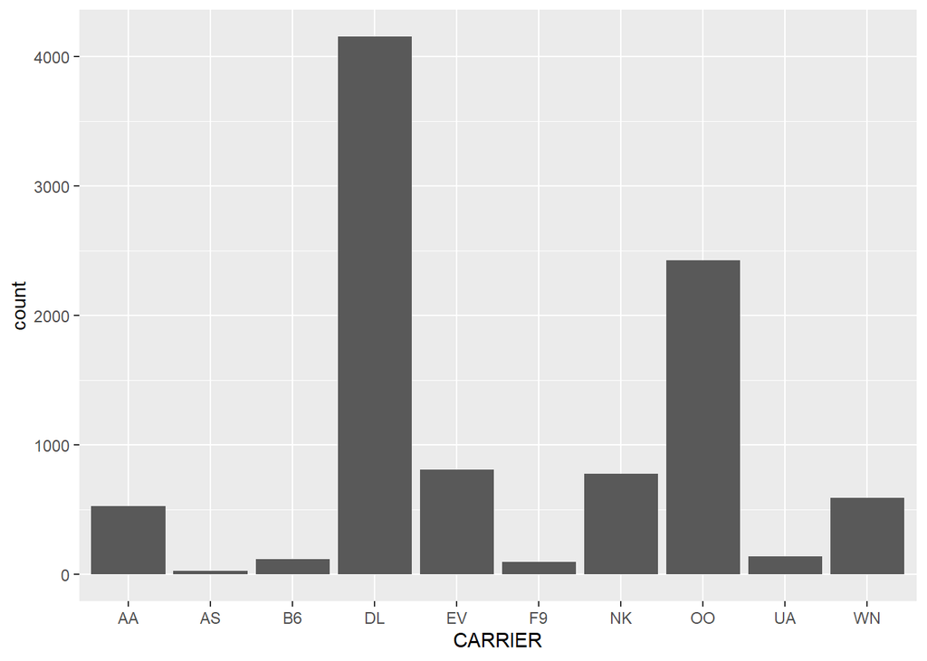

```r
ggplot(flights_out) + geom_bar(aes(x=CARRIER))
```

Now create a similar plot but instead of the bars being based on counts, make it be the mean DEP_DELAY. The key is to base your plot on the result of a **dplyr** query. Hint: You’ll also want to learn about the `stat` layer in ggplots.

This is a general strategy that is often useful for complex charts - create an intermediate dataframe that will make it “easy” to create the chart. Tools like **dplyr** (or **plyr** or **apply** family) are often a good choice for creating the intermediate dataframe.

For an additional challenge, try to order the bars so longest bars first.

Here’s what my solution looks like:

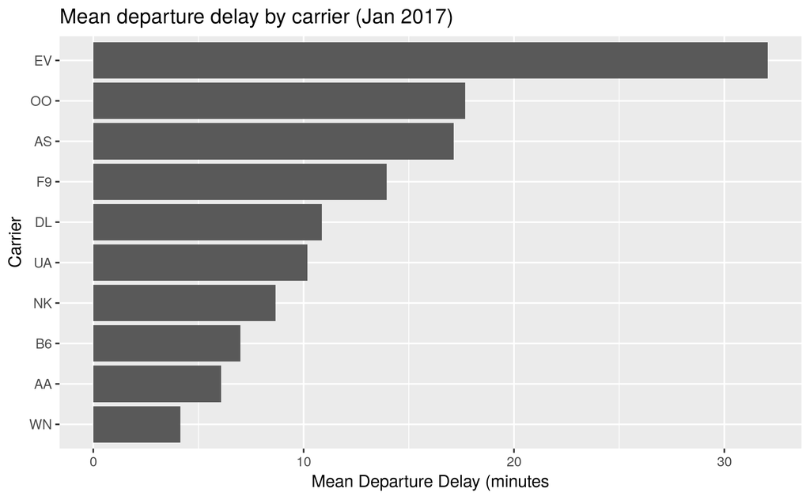

```r
knitr::include_graphics("images/mean_depdelay_carrier.png")
```

```r
mean_del_carr <- flights_out %>%
  group_by(CARRIER) %>%
  summarize(DEP_DELAY = (mean(DEP_DELAY, na.rm = TRUE)))
head(mean_del_carr)
```

```
## # A tibble: 6 x 2
##   CARRIER DEP_DELAY
##   <fct>       <dbl>
## 1 AA           6.08
## 2 AS          17.1
## 3 B6           7
## 4 DL          10.9
## 5 EV          32.1
## 6 F9          13.9
```

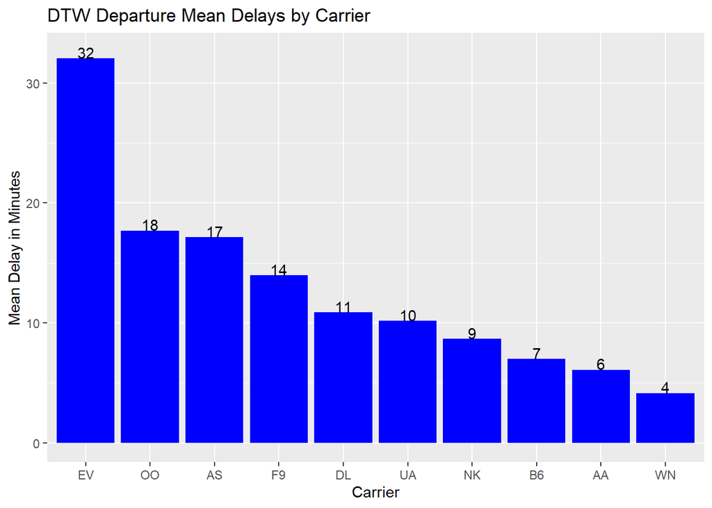

```r
mean_del_carr %>%
  ggplot(aes(x=reorder(CARRIER, -DEP_DELAY), y=DEP_DELAY)) +
  geom_bar(stat="identity", fill="blue") +
  labs(title = "DTW Departure Mean Delays by Carrier") +
  ylab("Mean Delay in Minutes") +
  xlab("Carrier") +
  geom_text(aes(x = CARRIER,
  y = DEP_DELAY + .5, label = round(DEP_DELAY, 0)))
```

**Hacker Extra #1 - Faceted density plots for high volume airports**

Create faceted (by ORIGIN) density plots of DEP_DELAY for those airports having greater than 200 flights.

Here’s what my solution looks like:

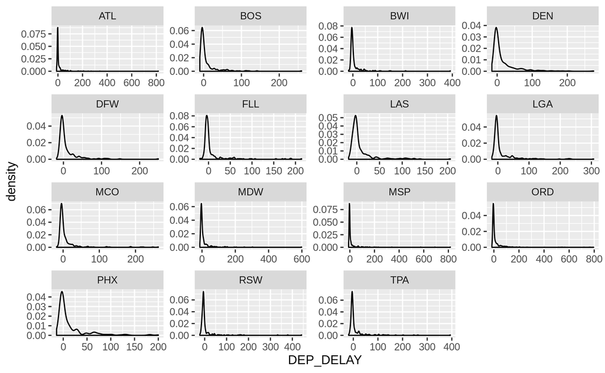

```r
knitr::include_graphics("images/depdelay_densities.png")
```

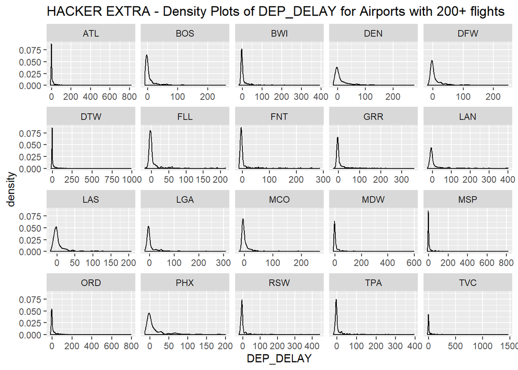

```r
flights %>%
  add_count(ORIGIN) %>%
  filter(n > 200) %>%
  group_by(ORIGIN) %>%
  ggplot(aes(DEP_DELAY)) + geom_density() +
  facet_wrap(~ORIGIN, scales='free_x') +
  labs(title = "HACKER EXTRA - Density Plots of DEP_DELAY for Airports with 200+ flights")
```

```r
#Hmmm mine has a few more airports listed than yours.  Better check the counts...
flights %>%
  group_by(ORIGIN) %>%
  summarize(num_flights = n()) %>%
  arrange(desc(num_flights)) %>%
  head(21)
```

```
## # A tibble: 21 x 2
##    ORIGIN num_flights
##    <fct>        <int>
##  1 DTW           9683
##  2 ORD           1222
##  3 GRR            903
##  4 ATL            672
##  5 MSP            427
##  6 MDW            379
##  7 FNT            374
##  8 MCO            323
##  9 LGA            315
## 10 DEN            307
## # ... with 11 more rows
```

```r
#I have 20 density plots so I will check to make sure the top 20 of 21 airports listed are 200+ flights

#Looks right to me :)
#Perhaps you filtered out N/A rows's on yours
```

### Hacker Extra -#2 - Average number of flights by day of week by carrier

Compute the average number of flights by day of week by carrier. Be careful - you must make sure that your solution works even if some carrier has a date on which they have no flights. Here’s what my solution looks like.

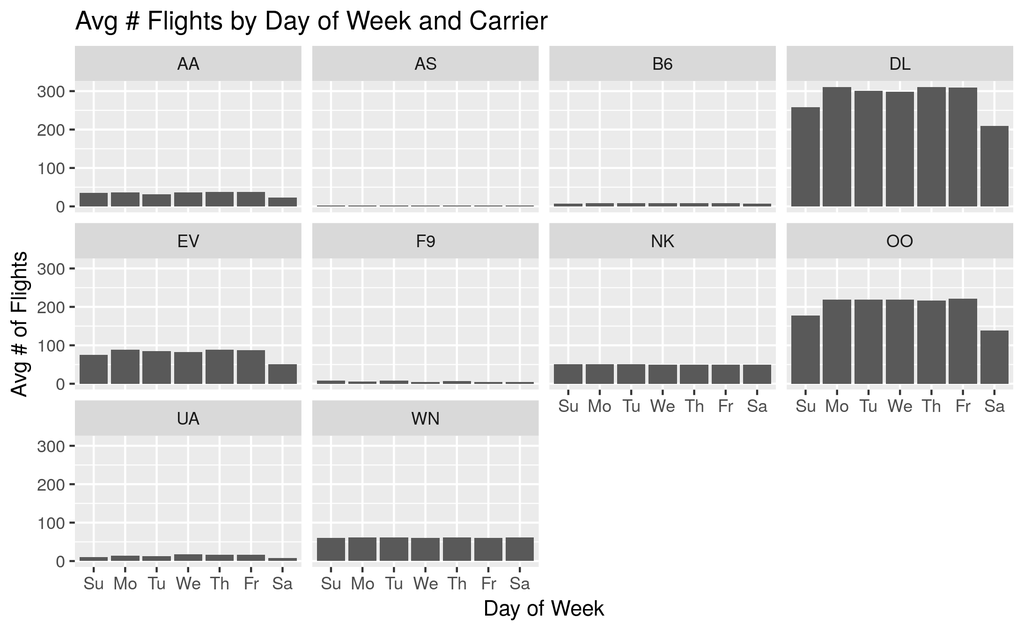

```r
knitr::include_graphics("images/flights_carrier_dow.png")
```

```r
# Apologies upfront... this is going to get messy lol
#Add dow column to flights
flights$FL_DOW <- wday(ymd(flights$FL_DATE), label = TRUE, abbr = FALSE)
  #head(flights)

#From original data
startDate <- min(flights$FL_DATE)
endDate <- max(flights$FL_DATE)

#Now build a sequence between the dates
allDates <-seq(from = startDate, to = endDate, by = "days")
#head(allDates)

#Create a data frame that counts num of dow for all dates in range
myDF <- data.frame(ALLDATES=allDates)
myDF$ALLDATES <- as.POSIXct(myDF$ALLDATES)
myDF$FL_DOW <- wday(ymd(myDF$ALLDATES), label = TRUE, abbr = FALSE)
myDF <- myDF %>%
  group_by(FL_DOW) %>%
  summarize(dow_count = n())

mynewtable <- merge(flights, myDF[, c("FL_DOW", "dow_count")], by="FL_DOW")
#head(mynewtable)

#Now, for what we were after...
mynewesttable <- mynewtable %>%
  add_count(CARRIER, FL_DOW) %>%
  mutate(dowabr = substr(FL_DOW, 1, 2)) %>%
  mutate(FlPerDOW = n/dow_count) %>%
  group_by_(.dots=c("CARRIER", "FL_DOW", "dowabr")) %>%
  summarize(avg_flights=mean(FlPerDOW))
head(mynewesttable)
```

```
## # A tibble: 6 x 4
## # Groups:   CARRIER, FL_DOW [6]
##   CARRIER FL_DOW    dowabr avg_flights
##   <fct>   <ord>     <chr>        <dbl>
## 1 AA      Sunday    Su            34.8
## 2 AA      Monday    Mo            37
## 3 AA      Tuesday   Tu            31.6
## 4 AA      Wednesday We            36.8
## 5 AA      Thursday  Th            38
## 6 AA      Friday    Fr            38
```

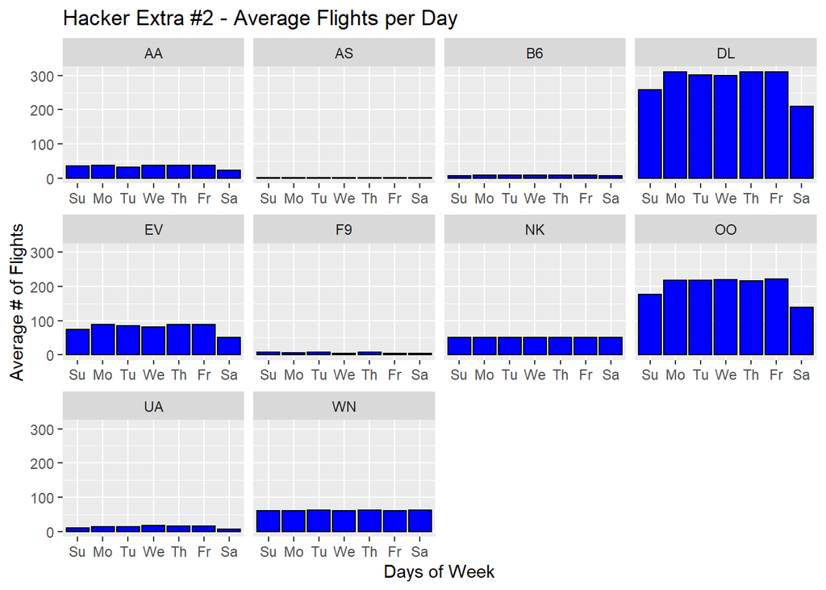

```r
#Need to order the abbreviated dow column
mynewesttable$dowabr <- factor(mynewesttable$dowabr,levels = c("Su", "Mo", "Tu", "We", "Th", "Fr", "Sa"))

mynewesttable %>%
  ggplot(aes(x=dowabr, y=avg_flights)) +
   geom_bar(stat="identity", colour="black", fill="blue") +
   labs(title = "Hacker Extra #2 - Average Flights per Day") +
   xlab("Days of Week") +
   ylab("Average # of Flights") +
   facet_wrap(~CARRIER, scales='free_x')
```

```r
# I eventually got there... but it was an ugly redundant path! That... was a battle
# https://github.com/MickiRhen/hw3_files
```

## Deliverables

Make sure all of your files are closed and saved and are inside your R project folder. Compress that entire folder and upload it via Moodle.